# Air Quality Modelling

Yawen Guan

For SAMSI Undergraduate Modelling Workshop

# Motivation

- Fine particulate matter (PM2.5) is a mixture of air pollutants that, at a high concentration level, has adverse effects on human health.
- Monitoring stations are deployed all over the US to measure total PM2.5 concentration.
- However monitor stations are sparse, many places are not in the monitoring network. Hence, other data sources are needed for predicting PM2.5.
- Another data source used by EPA to provide PM2.5 exposure estimate is the Community Multiscale Air Quality (CMAQ) model.
- In this workshop, we will develop statistical methods that predicts PM2.5 concentration level using numerical model outputs and other available covariates.
- Below are some R codes to help you get started.

# Load R package and Data Sets

- We will use the *fields* R packages for plotting. It also contains lots of other useful functions, see the fieldsVignette html file for more information.
- In the R file, there are two data files.
- File “dat” contains the location, day of the year, and concentration of PM2.5 measured at the monitoring sites, as well as some other possible variables that can help predicting PM2.5.
- File “mappred_df” contains all variables in dat file except PM2.5.
- We will built and test the statistical models using “dat” file, and finally create map prediction using file “mappred_df”
- Let’s first take a look at the data set and make some plots.

```r
library(fields)
load(file = "AirQ_SAMSI_UG.Rda")
ls()
```

```
## [1] "dat"        "mappred_df"
```

```r
str(dat)
```

```
## 'data.frame':    115932 obs. of  32 variables:
##  $ PM            : num  3.5 3.6 4 5.5 10.5 15.7 6.3 4.8 32.8 13.8 ...
##  $ Site          : int  10730023 10732003 51190007 51191008 60010007 60130002 60190008 60290014 60371002 60371103 ...
##  $ Longitude     : num  -86.8 -86.9 -92.3 -92.3 -121.8 ...
##  $ Latitude      : num  33.6 33.5 34.8 34.7 37.7 ...
##  $ t             : int  1 1 1 1 1 1 1 1 1 1 ...
##  $ elev          : num  171.5 182.8 74.7 71.6 287.4 ...
##  $ emissi11_pm25 : num  0 3.78 0 0 0 ...
##  $ forest_cover  : num  0.55704 0 0.05709 0.03765 0.00535 ...
##  $ high          : num  0 66 1079 0 0 ...
##  $ limi          : num  0 0 0 0 0 ...
##  $ local         : num  0 1872 520 0 554 ...
##  $ is            : num  3.31 82.11 3.94 0 13.19 ...
##  $ pd            : num  171.3 1656.5 492.9 31.6 12.7 ...
##  $ nldas_pevapsfc: num  0.229 0.217 0.328 0.328 0.094 ...
```

[output cut: 18 more lines]

### Where are the Monitors?

- Let’s take a look at the sites.
- **Try plotting this for different day of the year and see what changes.**

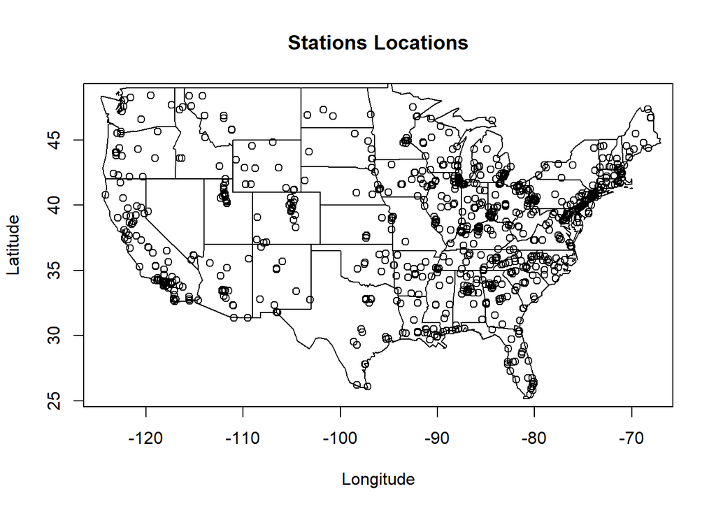

```r
with(dat, plot(Longitude, Latitude, main="Stations Locations"))
US(add=T)
```

### Visualize PM2.5 Concentration Level

- The R code below plots PM2.5 concentration on a particular day.

```r
set.panel(2,2)
```

```
## plot window will lay out plots in a 2 by 2 matrix
```

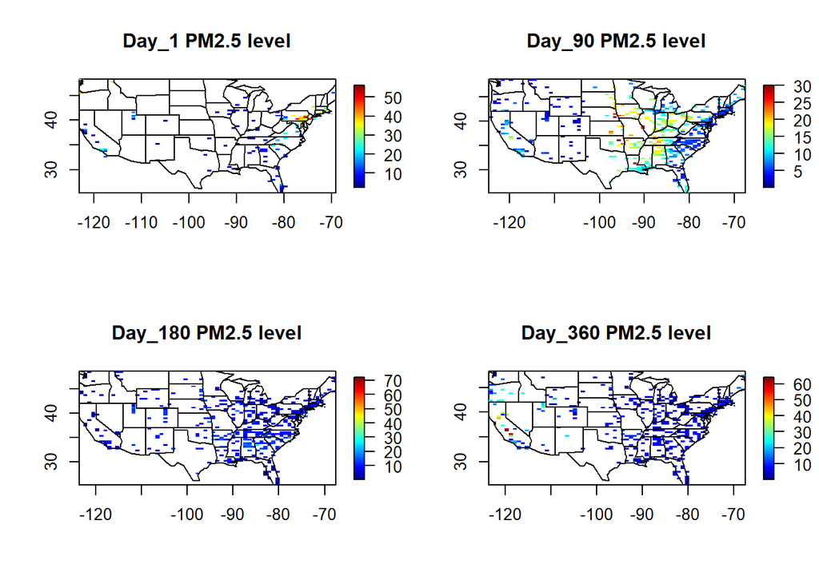

```r
for(day in c(1,90,180,360)){
  with(subset(dat,t==day), quilt.plot(Longitude, Latitude, PM, main=paste0("Day_",day," PM2.5 level")))
  US(add=T)
}
```

- **It may not be easy to see the spatial distribution, how about take the logarithm of the concentrations**
- **There are many other ways to visualize these data, for example, plotting concentration against other variables to see if there are any obvious relationships.**
- i.e. How does monitoring data compares with CMAQ on a particular day

```r
set.panel(1,2)
```

```
## plot window will lay out plots in a 1 by 2 matrix
```

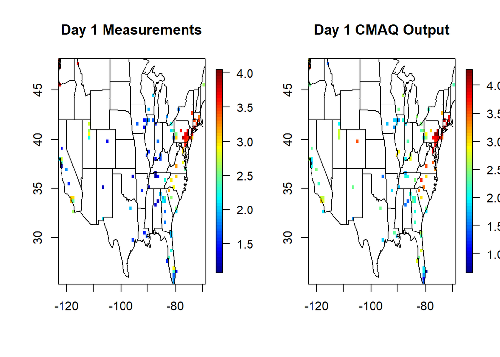

```r
with(subset(dat,t==1), quilt.plot(Longitude, Latitude, log(PM),main="Day 1 Measurements"))
US(add=T)
with(subset(dat,t==1), quilt.plot(Longitude, Latitude, log(CMAQ1),main="Day 1 CMAQ Output"))
US(add=T)
```

- **Can you think of some other exploratory analyses?**

### Cross validation.

- Cross-validation is a technique to evaluate predictive models by partitioning the original sample into a training set to train the model, and a test set to evaluate it.
- The last column of the file “dat” is called folds, and there are 5 folds in total.
- **You will build a statistical method using any four folds, says fold = 1,2,3,4, then make prediction for fold 5, as a way to evaluate your statistical model.**
- **Now you can brainstorm for ideas on modeling PM2.5, try some of you favorite statistcal models!**
- **There are different ways to evaluate how well your prediction matches with the observations. Can you name a few?**

### Making map prediction.

- mappred_df file contains CMAQ and covariates on a grid
- We will make prediction maps for 1/1/2011 and 8/1/2011
- First lets take a look at what the file contains and make some plots.

```r
str(mappred_df)
```

```
## 'data.frame':    107614 obs. of  29 variables:
##  $ Longitude     : num  -97.6 -97.5 -97.9 -97.8 -97.6 ...
##  $ Latitude      : num  25.9 25.9 26.1 26.1 26.1 ...
##  $ t             : num  1 1 1 1 1 1 1 1 1 1 ...
##  $ elev          : num  10.24 4.39 17.82 12.61 8.24 ...
##  $ emissi11_pm25 : num  0 0 0 0 0 0 0 0 0 0 ...
##  $ forest_cover  : num  0.03922 0.00735 0.10652 0.04775 0.21123 ...
##  $ high          : num  0 0 1079 0 0 ...
##  $ limi          : num  0 0 0 0 0 0 0 0 0 0 ...
##  $ local         : num  832 1634 306 0 1009 ...
##  $ is            : num  30.2 46.85 12.22 20.44 7.77 ...
##  $ pd            : num  1467.7 28.5 78.1 131.6 125.8 ...
##  $ nldas_pevapsfc: num  0.505 0.479 0.49 0.496 0.503 ...
##  $ nldas_dlwrfsfc: num  347 344 350 348 345 ...
##  $ nldas_dswrfsfc: num  459 470 422 431 456 ...
##  $ nldas_cape    : num  0 0 0 0 0 0 0 0 0 0 ...
##  $ nldas_rh2m    : num  57.7 61.9 53.2 55.8 58.8 ...
##  $ nldas_tmp2m   : num  295 294 294 294 294 ...
##  $ nldas_vgrd10m : num  -7.15 -8.02 -5.58 -6.46 -7.38 ...
##  $ nldas_ugrd10m : num  -0.861 -1.119 -0.781 -1.133 -1.509 ...
##  $ nldas_pressfc : num  101651 101662 101572 101604 101624 ...
##  $ narr_dpt      : num  286 286 284 287 287 ...
##  $ narr_vis      : num  20006 20006 20006 20006 20006 ...
##  $ narr_hpbl     : num  927 927 972 885 885 ...
##  $ narr_rh2m     : num  59 59 54.1 62.2 62.2 ...
##  $ narr_tmp2m    : num  295 295 294 294 294 ...
##  $ narr_ugrd10m  : num  -0.589 -0.589 -1.167 -2.05 -2.05 ...
##  $ narr_vgrd10m  : num  -6.88 -6.88 -5.63 -7.92 -7.92 ...
##  $ narr_tmp1815mb: num  285 285 284 284 284 ...
##  $ CMAQ1         : num  8.21 10.33 7.57 8.78 8.4 ...
```

- Visualize CMAQ data for 1/1/2011 and 8/1/2011

```r
set.panel(1,2)
```

```
## plot window will lay out plots in a 1 by 2 matrix
```

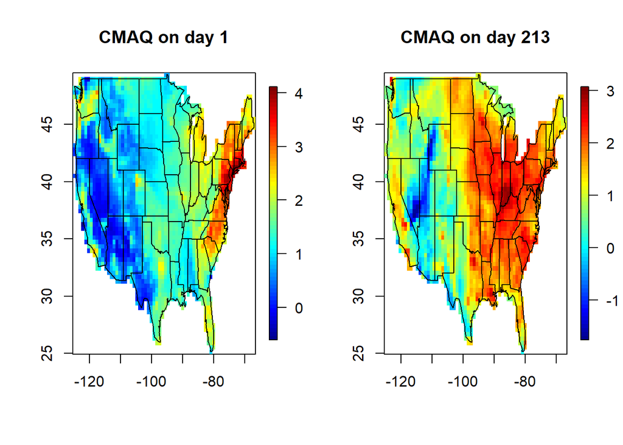

```r
with(subset(mappred_df,t==1),
     quilt.plot(Longitude, Latitude, log(CMAQ1),main="CMAQ on day 1"))
US(add=T)
with(subset(mappred_df,t==213),
     quilt.plot(Longitude, Latitude, log(CMAQ1),main="CMAQ on day 213"))
US(add=T)
```

- **Once you have your statistical model ready, you can now make prediction maps for PM2.5 for the entire US!**